# 2007-2016 Arasında Dunya Ulkeleri Otomotiv Uretimi

Süheyla Çakmak , Burçin Avşar

Bu çalışmamızda OICA web sitesinden http://www.oica.net/category/production-statistics/2007-statistics/ edinilen veriler kullanılarak 2007-2016 yılları arasında Dünya otomotiv sektöründe üretilen araçların sayılarının değişimi incelenmiştir.

# Verilerin Derlenmesi

http://www.oica.net/category/production-statistics/2007-statistics/ sitesinde yıllık olarak ayrı raporlarda tutulan üretim verilerini önce Microsoft Excel kullanılarak birleştirilmiş, veri yapısı düzenlenmiş ve 10 yıllık üretim verisi oluşturulmuştur.veri=read.table(“C:/Users/SÜHEYLA ÇAKMAK/Desktop/Otomotiv_Uretim.csv”,sep=“;”,header = T,dec=“,”) komutu kullanılarak R ortamına aktarılmıştır.

```r
library(tidyverse)
library(dplyr)
library(tidyr)
library(ggplot2)
require(data.table)
setwd("C:\\Users\\SÜHEYLA ÇAKMAK\\Desktop\\")
veri=read.table("C:/Users/SÜHEYLA ÇAKMAK/Desktop/otomotiv_uretimi.csv",sep=";",header = T,dec=",")
otomotiv2=
  veri %>%
  gather(key=YILLAR,value=uretim,-ULKE)
```

Bazı Asya ülkeleri filtrelenerek 10 yıllık süreçte otomotiv üretimleri veri seti oluşturulmuş ve grafikte gösterilmiştir

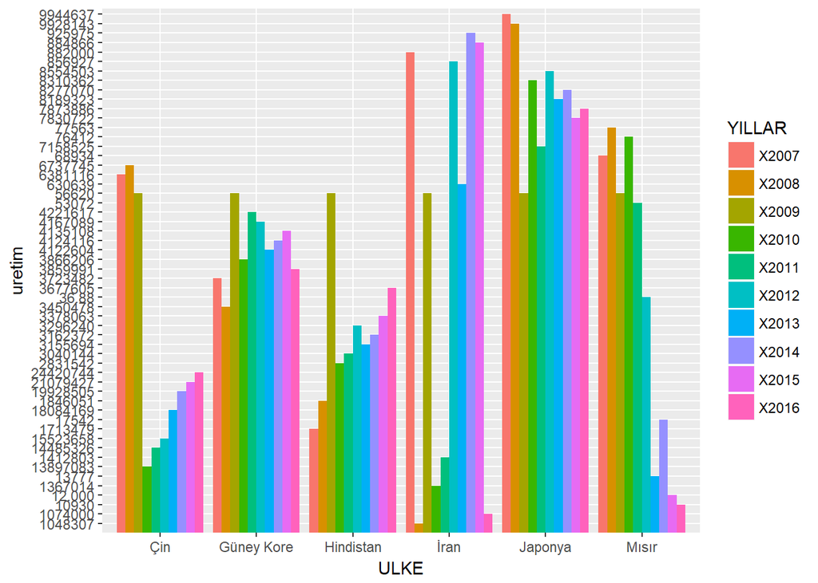

```r
asya_ulkeleri=
  otomotiv2 %>%
  filter(ULKE == "Çin" | ULKE == "Hindistan"|ULKE == "Mısır" | ULKE == "İran" | ULKE == "Japonya"|ULKE == "Güney Kore")
ggplot(data=asya_ulkeleri,aes(x=ULKE,y=uretim,fill=YILLAR,group=YILLAR))+geom_bar(stat="identity",position = "dodge")
```

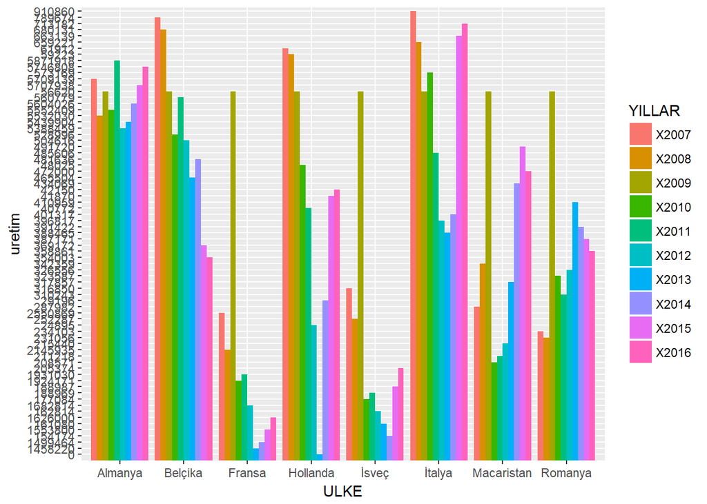

```r
ab_ulkeleri=
  otomotiv2 %>%
  filter(ULKE == "Belçika" | ULKE == "Fransa" | ULKE == "Almanya"|ULKE == "Macaristan" | ULKE == "İtalya"|ULKE == "Hollanda"|ULKE == "İspanya"|ULKE == "İsveç"|ULKE == "Romanya" )
ggplot(data=ab_ulkeleri,aes(x=ULKE,y=uretim,fill=YILLAR,group=YILLAR))+geom_bar(stat="identity",position = "dodge")
```

Dikkat çeken bir diğer ülke ise 2013’te hiç üretim yapmamış olan Hollanda. 2013’e dek istikrarlı bir azalış görünüyor. 2013’ten sonra ise her yıl üretim miktarlarının düzenli olarak artışı gözlemlenmiştir.

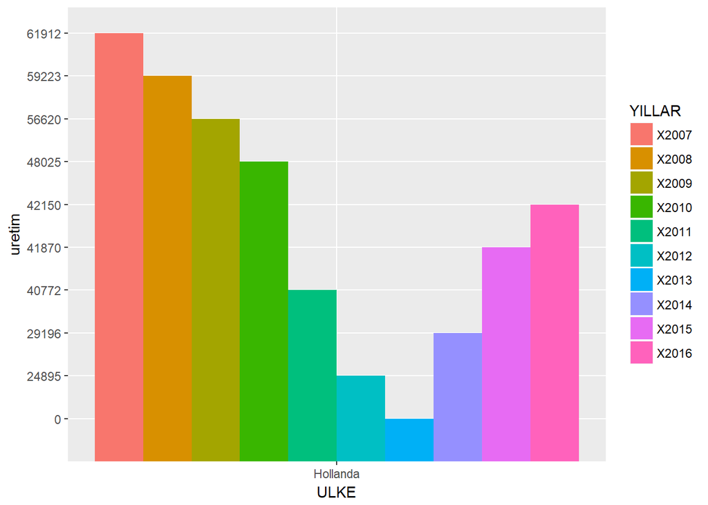

```r
Hollanda=
  otomotiv2 %>%
  filter(ULKE=="Hollanda")
ggplot(data=Hollanda,aes(x=ULKE,y=uretim,fill=YILLAR,group=YILLAR))+geom_bar(stat="identity",position = "dodge")
```

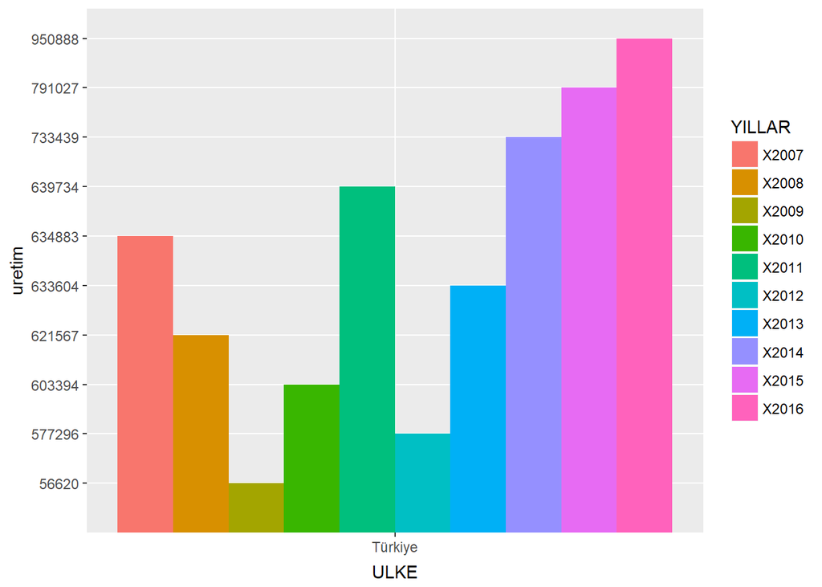

```r
Turkiye=
  otomotiv2 %>%
  filter(ULKE=="Türkiye")
ggplot(data=Turkiye,aes(x=ULKE,y=uretim,fill=YILLAR,group=YILLAR))+geom_bar(stat="identity",position = "dodge")
```

# Sonuç